# Machine Learning: AllLife Bank Personal Loan Campaign

## Data Preprocessing

- Missing value treatment
- Feature engineering (if needed)
- Outlier detection and treatment (if needed)
- Preparing data for modeling
- Any other preprocessing steps (if needed)

#### Outliers detection

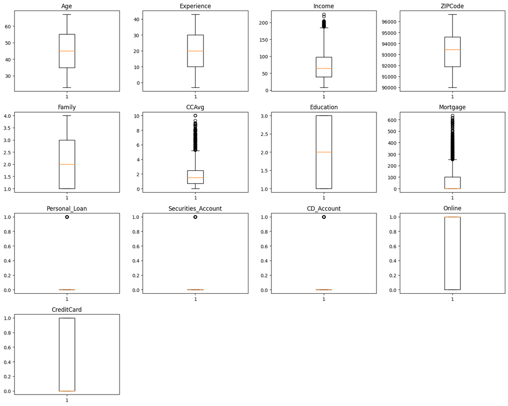

```python
numeric_columns = data.select_dtypes(include=np.number).columns.tolist()

plt.figure(figsize=(15,12))

for i, variable in enumerate(numeric_columns):
  plt.subplot(4,4,i+1)
  plt.boxplot(data[variable],whis=1.5)
  plt.tight_layout()
  plt.title(variable)

plt.show()
```

Observations:

- There are quite a few outliers, but these are proper values of customers' financial behaviors or profiles, and are needed for the data modeling.

#### Data Preparation for Modeling

```python
x = data.drop(["Personal_Loan"],axis=1)
y = data["Personal_Loan"]

x = pd.get_dummies(x, drop_first=True)

#Splitting data in train and test sets
x_train, x_test, y_train, y_test = train_test_split(
    x,y,test_size=0.30,random_state=1
)
```

```python
print("Shape of Training set: ", x_train.shape)
print("Shape of test set: ", x_test.shape)
print("Percentage of classes in training set:")
print(y_train.value_counts(normalize=True))
print("Percentage of classes in test set:")
print(y_test.value_counts(normalize=True))
```

```
Shape of Training set:  (3500, 12)
Shape of test set:  (1500, 12)
Percentage of classes in training set:
0   0.90543
1   0.09457
Name: Personal_Loan, dtype: float64
Percentage of classes in test set:
0   0.90067
1   0.09933
Name: Personal_Loan, dtype: float64
```

- We had seen that around 90.5% of observations belong to class 0 (No Loan ) and 9.45% of observations belong to class 1 (Loan), and this is preserved in the train and test sets.